# A Bayesian view

## Overview

- Variational formulations
- A probabilistic view and Bayes' Law
- Modelling tools

# Variational formulations

We've seen Tikhonov

$$\min_u \|Ku - f\|_2^2 + \alpha \|u\|_2^2,$$

which we can generalise to

$$\min_u \|Ku - f\|_2^2 + \alpha \|Lu\|_2^2.$$

Other norms are popular as well:

$$\min_u \|Ku - f\|_2^2 + \alpha \|u\|_1,$$

or

$$\min_u \|Ku - f\|_2^2 + \alpha \|Lu\|_1$$

We can even use different data-fidelity terms

$$\min_u \|W(Ku - f)\|_2^2 + \alpha \|u\|_2^2,$$

or, in general,

$$\min_u \mathcal{L}(Ku, f) + \alpha \mathcal{R}(u).$$

# A probabilistic view and Bayes' Law

Consider a stochastic description of the measurement process, with probability density

$$\pi_{\text{like}}(f | u),$$

and a probability distribution encoding prior knowledge on $u$

$$\pi_{\text{prior}}(u).$$

The *posterior* distribution describes a probability distribution over $u$, conditioned on given measurements $f$:

$$\pi_{\text{post}}(u | f) \propto \pi_{\text{like}}(f | u)\pi_{\text{prior}}(u).$$

Estimate density of rock sample $\rho = w/v$ [g/cm^3] from measurements of weight $w$ and volume $v$:

- Assume $w^\delta = w + \epsilon_{w}$ and $v^\delta = v + \epsilon_{v}$, where $\epsilon_w,\epsilon_v$ are normally distributed with mean zero and variance $\sigma^2$
- We have $w^\delta - \rho v^\delta = \epsilon_w - \rho \epsilon_v$
- Thus, $w^\delta - \rho v^\delta$ is a normally distributed random variable with mean zero and variance $\sigma^2(1 + \rho^2)$

This gives us the following Likelihood

$$\pi_{\text{data}}(w^\delta, v^\delta | \rho) = \frac{1}{\sigma\sqrt{1+\rho^2}\sqrt{2\pi}}\exp\left(-\frac{(w^\delta - \rho v^\delta)^2}{2\sigma^2(1+\rho^2)}\right).$$

As prior, we can use statistics of rock samples, which is a log-normal disrtibution with parameters $(1.5,0.4)$.

[figure not shown]

Measure a smooth signal

$$f^\delta_i = u(x_i) + \epsilon_i,\quad i \in \{0,1,\ldots, n-1\},$$

where $\epsilon_i \sim N(0,\sigma^2)$ and $u(x_i) \sim N(0,\Sigma)$, with

$$\Sigma_{ij} = \exp\left(-\frac{|i-j|^2}{2L^{2}}\right).$$

Estimate $u$ by solving:

$$\min_u \|u - f^\delta\|_2^2 + \alpha \|u\|_{\Sigma^{-1}}^2.$$

Here, $\alpha$ is an estimate of the variance of the noise, so ideally we have $\alpha \approx \sigma^{2}$. The corresponding posterior mean and covariance are given by

$$\mu_{\text{post}} = \left(\alpha I + \Sigma\right)^{-1}\Sigma f^\delta,$$$$\Sigma_{\text{post}} = \alpha \left(\alpha I + \Sigma\right)^{-1}\Sigma.$$

[figure not shown]

# Modelling tools

How do we come up with probability distributions for the likelihood or prior?

- Hand-crafted feature models
- Classical methods: dictionary learning, k-means clustering, PCA, Gaussian Mixture Models
- Unsupervised machine learning

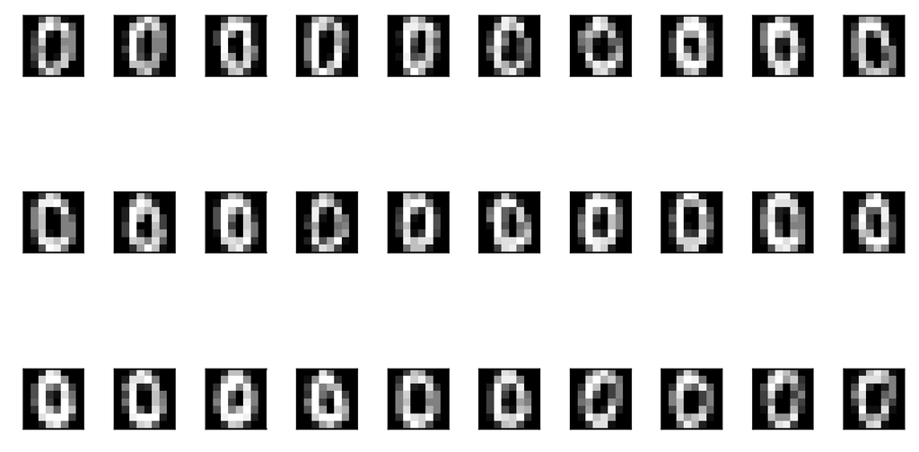

```python
show_data(U_train[:30],3,10)
```

```python
mu    = np.mean(U_train,axis=0)
Sigma = (U_train.T@U_train)/U_train.shape[0]
R     = np.linalg.cholesky(Sigma + 1e-16*np.eye(64))

U = np.reshape(mu,(64,1)) + R@np.random.randn(64,30)
```

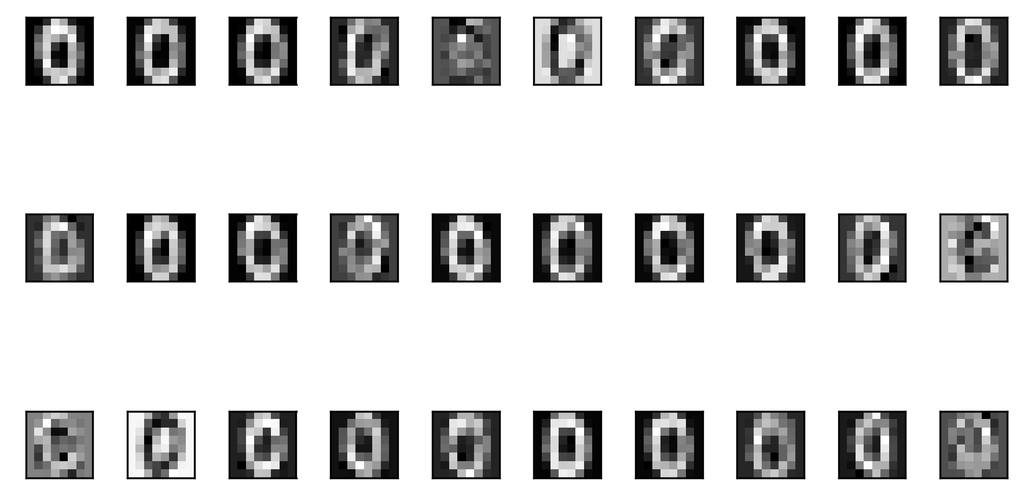

```python
show_data(U.T,3,10)
```

# Exercise

See https://github.com/TristanvanLeeuwen/Summerschool/blob/main/DictionaryLearning.ipynb